# MBP Tech Talks - DNA Sequencing

# MBP Tech Talks

## Fall 2019

Fundamentals of Genome Sequencing and Applications

# Motivations

- Lots of research involves genome sequencing or and analysis
- Few resources covering the fundamentals
- Information is often scattered through blog posts, presentations
- Multidisciplinary - difficult for a single person to discuss thoroughly

# Goals for the fall semester

- Understand foundations of genome sequencing
  - How DNA is captured and read
  - What makes good sequencing data
- Sequence alignment
- Wet and dry sides of sequencing experiments
- How to think about good experiment design when sequencing

# Outline

- Fundamentals of genome sequencing
  - History of reading DNA
  - Massively-parallel sequencing
  - Standard file formats
  - Sequence alignment
  - Alignment metrics
- Applications
  - Mutation detection
  - Chromatin accessibililty
  - Histone modifications and protein binding
  - Transcriptome sequencing
  - Chromatin organization
  - DNA methylation
- Extended topics

## Session structure

- HSB 100, Friday 12:00 - 14:00
- No food or drinks
- Each session has 2 parts, break in the middle

# DNA molecules

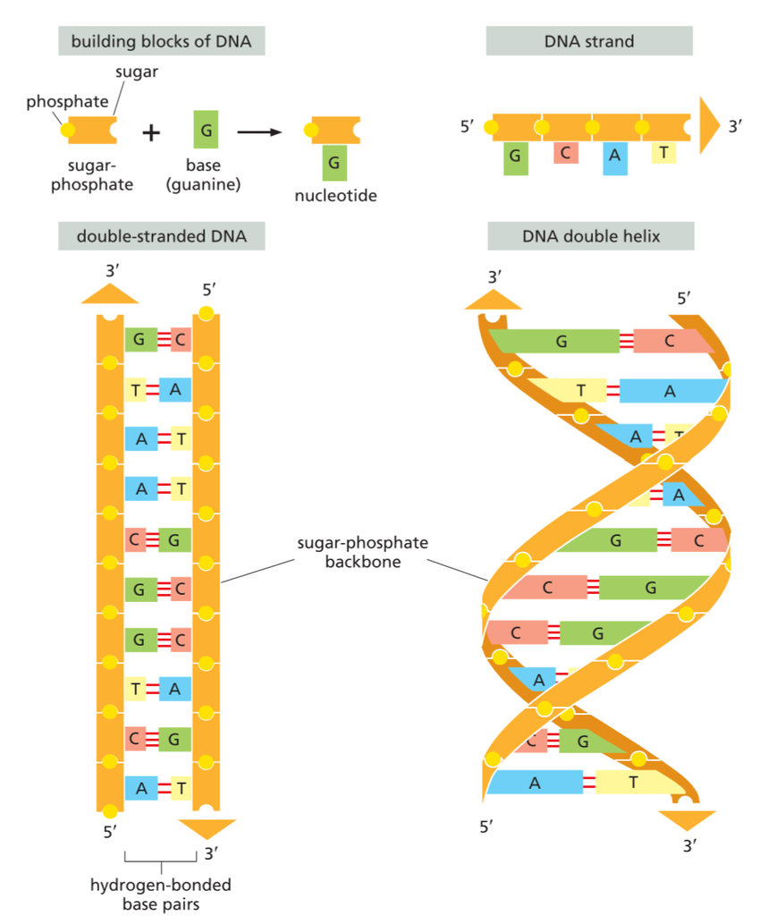

DNA structure

.footnote[ [1] Alberts, Molecular biology of the cell, 6ed. pg. 176]

- DNA is double-stranded polymer
  - DNA contains 4 nucleotides: adenine (A), cytosine (C), guanine (G), thymine (T)
  - DNA has a sugar-phosphate backbone
  - Nucleotides come in complementary pairs: A-T, C-G

# DNA molecules

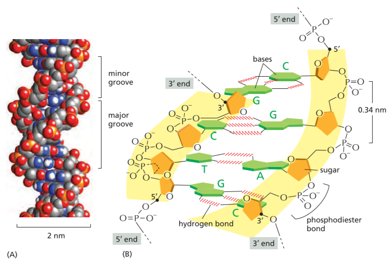

DNA structure

- DNA has a right-handed orientation
  - Strands are oriented in opposite directions
  - We measure direction by counting 5’ to 3’

.footnote[ [2] Alberts, Molecular biology of the cell, 6ed. pg. 177]

# DNA encodes information for organisms

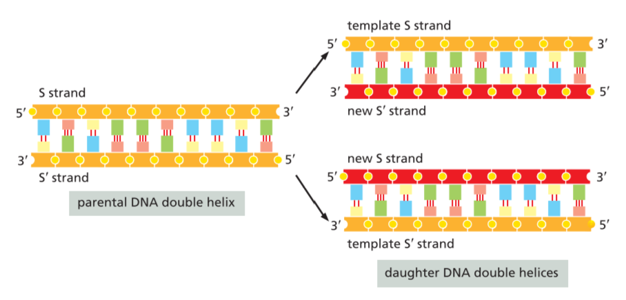

DNA replication

- Complementary strands allow for replication
- Sequences themselves code for proteins inside cells
- Genome: set of all DNA inside an organism/cell
- DNA sequencing: the process of measuring the order of these nucleotides

.footnote[ [3] Alberts, Molecular biology of the cell, 6ed. pg. 178]

# Early DNA sequencing - Sanger sequencing